# Final report

Wenyu Zhu, Tianran Zhang, Yinuo Liu

2020/7/16

# Study Background

# Roadmap

## Step 0: Scientific Question

**What is the causal effect of physical activities on depression among American adults age 20-65?**

## Step 1: Causal Model

We built a structural causal models to represent our background knowledge of the system we studied.

**Specify the causal model**  
To build the structural causal model, we need to specify the endogenous variable X, the background variable U and the structural equations F. The endogenous variables are affected by other variables in the model. The background variables are all the unmeasured factors not included in X and determine the values that the X variables take. The structural equations deterministically assign a value to each of the endogenous variables X.

**Structural Causal Model (SCM)**

- Endogenous nodes: $X =(W, A, Y)$, where $W$={sociodemographic information, comorbidities, disabilities, drug use, alcohol use, sleep disorder, self-reported health condition}, A is physical activity status, and Y is depression status.
- Background (exogenous) variables: $U=(U_{W}, U_{A}, U_{Y})\sim \mathrm{P}^*$, where $U_W$={occupation, citizenship}, $U_A$={diet,physique} $U_Y$={personality,stress}. There are no independence assumptions on $P^*$.
- Structural equations $F$:

$$\begin{align*}
W& \leftarrow f_{W}(U_W)\\
A& \leftarrow f_A(W, U_A)\\
Y& \leftarrow f_{Y}(W, A, U_Y)
\end{align*}$$

**DAG**  
The accompanying directed acyclic graph (DAG) graphically shows the structural equations.

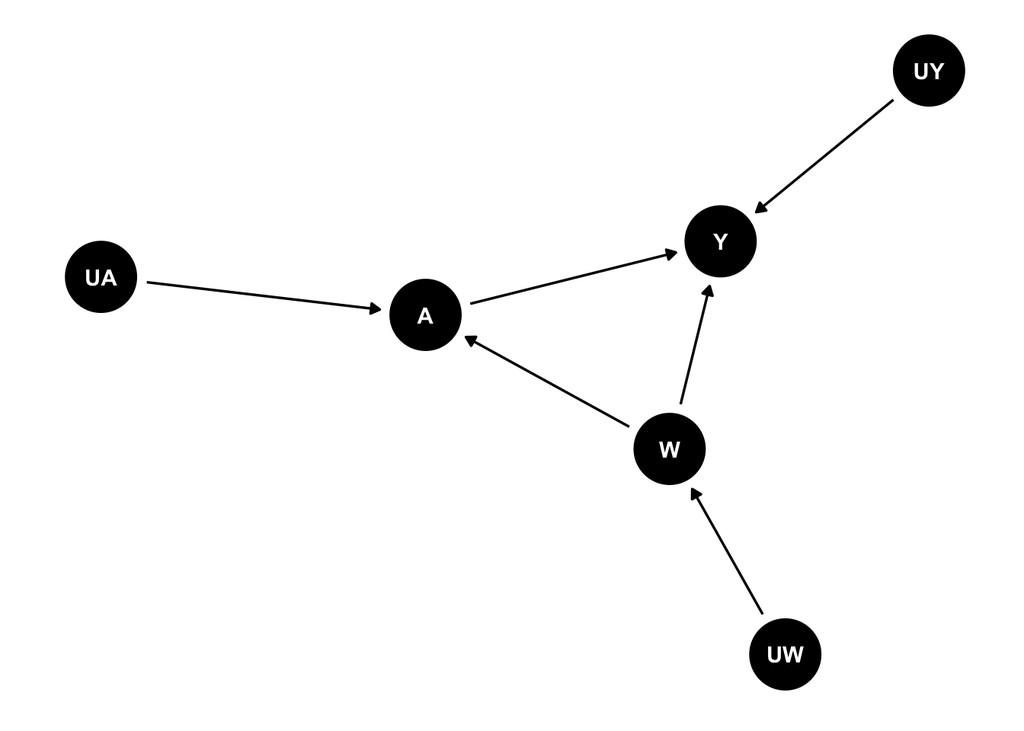